# DataCleanUpTreatmentFinal

Autumn

17/07/2021

# Setup and Initiation

First we remove all variables of the global environment and load in all functions, data, and packages to be used. Furthermore, all data sets to be used have their information void columns and rows removed. Then all prism data is dose correlated, meaning that a drugs effect on cell growth is normalised to the applied dosage (doscor). Morevover, this doscor data is further processed, where the mean is taken of each drug’s effect per dosage (perdrug). All three—prism, prism.doscor, and prism.perdrug—are then split each into a data set, containing only data for pancreatic cancer cell lines and further into data sets, each containing only cell lines of one of the four subtypes of pancreatic cancer as identified in prism.treat.

```r
knitr::opts_chunk$set(echo = TRUE)
source("Scripts/InitiatorFinal.R")
```

# Identification of effective drugs

```r
#   first is for doscor, second for perdrug
th <- "q.005"
source("./Scripts/EfDrIdentifierFinal.R")
```

# Having a look at the most effective drugs

```r
message("ef.pancan.perdrug")
```

```
## ef.pancan.perdrug
```

```r
print(dr.to.effect(as.vector(ef.pancan.perdrug), doscor = 2))
```

```
## $`exatecan-mesylate`
## [1] -747.9651
##
## $`SB-743921`
## [1] -660.5004
##
## $triptolide
## [1] -641.4677
##
## $`SN-38`
## [1] -596.9951
##
## $`maytansinol-isobutyrate`
## [1] -510.6381
##
## $`oligomycin-a`
## [1] -446.5851
##
## $alvespimycin
## [1] -357.9862
```

# Preparing data for kmeans clustering

To cluster our cell lines in respect to drug efficacies per dosage, we decided to only use the 100 drugs with the highest variance. To check how many clusters are reasonable we used the elbow method.

```r
topVar <- apply(df.NA.to.val(pancan.perdrug, 2, "median"), 2, var)
pancan.perdrug.topVar <- df.NA.to.val(pancan.perdrug, 2, "median")[, topVar >= sort(topVar, decreasing = T)[100]]
```

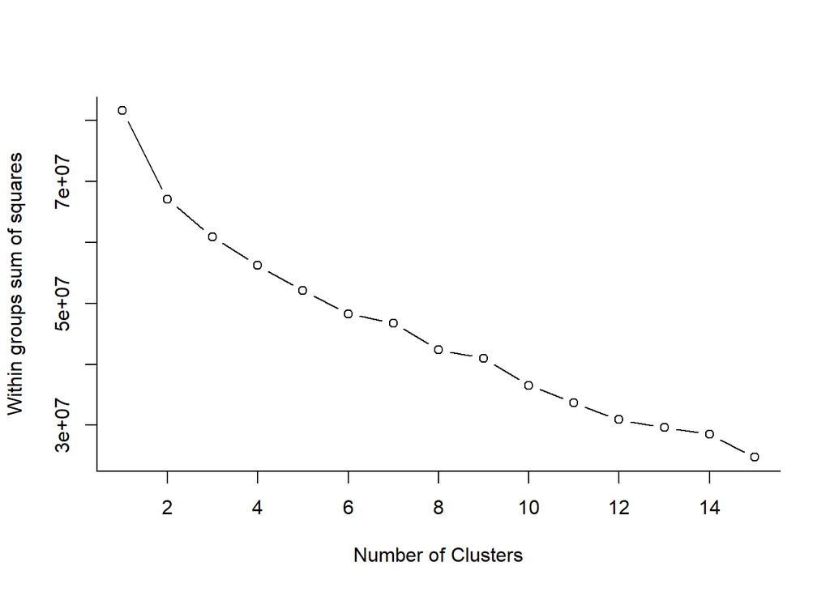

```r
wss <- (nrow(pancan.perdrug.topVar) - 1) * sum(apply(pancan.perdrug.topVar, 2, var))
for (i in 2:15) wss[i] <- sum(kmeans(pancan.perdrug.topVar, centers=i)$withinss)

plot(1:15, wss, type="b", xlab="Number of Clusters", ylab="Within groups sum of squares", bty = "l")
```

# K-means clustering

Since the above graph exhibited a kink at i = 2 we chose to use two clusters.

```r
km = kmeans(x=pancan.perdrug.topVar,
            centers = 2,
            nstart = 100)
summary(km)
```

```
##              Length Class  Mode
## cluster       33    -none- numeric
## centers      200    -none- numeric
## totss          1    -none- numeric
## withinss       2    -none- numeric
## tot.withinss   1    -none- numeric
## betweenss      1    -none- numeric
## size           2    -none- numeric
## iter           1    -none- numeric
## ifault         1    -none- numeric
```

To further verify, that our choice of two clusters is the best choice, we check which amount of clusters has the highest average silhouette width. The result shows us that a clustering with two clusters is optimal.

```r
avs <- c()
for (i in 2:{nrow(pancan.perdrug.topVar)-1}) {
  km <- kmeans(x = pancan.perdrug.topVar,
            centers = i,
            nstart = 100)
  D <- dist(pancan.perdrug.topVar)
  avs <- append(avs, summary(silhouette(km$cluster, D))$avg.width)
}
print(avs); print(avs[which(avs == max(avs))]); print(which(avs == max(avs)) + 1)
```

```
##  [1] 0.15687127 0.09708832 0.05149854 0.05552384 0.05657905 0.05603248
##  [7] 0.05823367 0.05821152 0.05407538 0.05519260 0.05754825 0.05413175
## [13] 0.04600504 0.05654601 0.05231767 0.04572642 0.04446389 0.03936107
## [19] 0.04247993 0.04400559 0.04554871 0.04267169 0.04307741 0.04002622
## [25] 0.04000158 0.03509645 0.02640868 0.02474554 0.01923425 0.01241012
## [31] 0.00413415
```

```
## [1] 0.1568713
```

```
## [1] 2
```

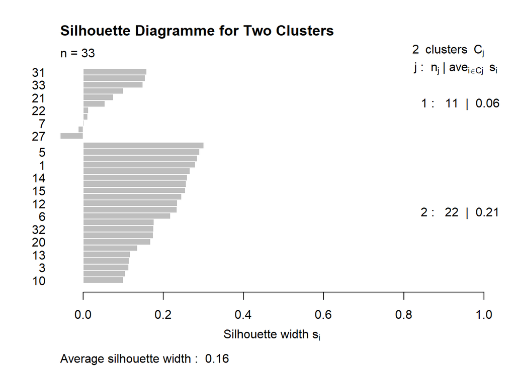

```r
plot(silhouette(kmeans(x = pancan.perdrug.topVar, centers = 2, nstart = 100)$cluster, dist(pancan.perdrug.topVar)), main = "Silhouette Diagramme for Two Clusters")
```

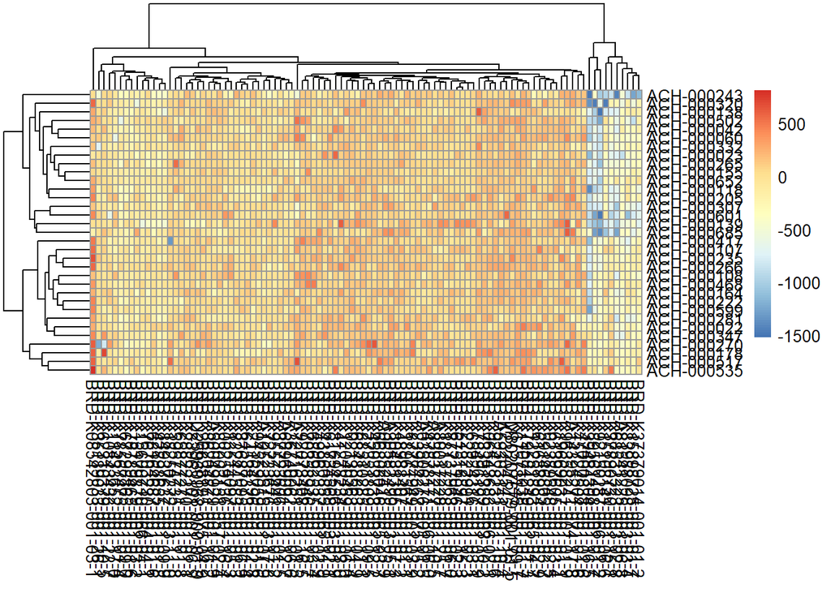

```r
pheatmap::pheatmap(pancan.perdrug.topVar)
```